# EDA

```r
library(tidyverse)
library(reshape2)
library(matrixStats)
library(GGally)
data_url <- 'https://raw.githubusercontent.com/jyurko/INFSCI_2595_Spring_2021/main/HW/final_project/infsci_2595_s21_final_project_data.csv'

df <- readr::read_csv(data_url, col_names = TRUE)
df %>% glimpse()
```

```
## Rows: 2,013
## Columns: 15
## $ xA         <chr> "A1", "A1", "A1", "A1", "A1", "A1", "A1", "A1", "A1", "A1",~
## $ xB         <chr> "B1", "B1", "B1", "B1", "B1", "B1", "B1", "B1", "B1", "B1",~
## $ x01        <dbl> 83.54072, 83.54778, 86.32736, 84.86205, 82.46256, 80.99029,~
## $ x02        <dbl> 287.7955, 290.8875, 349.7162, 299.6924, 329.2035, 269.7590,~
## $ x03        <dbl> 119.8126, 130.1864, 115.5560, 143.8517, 123.6961, 119.8614,~
## $ x04        <dbl> 383.3652, 337.7157, 357.4333, 387.0575, 347.6050, 270.1010,~
## $ x05        <dbl> 338.3202, 330.4228, 354.0787, 297.0156, 379.7120, 243.2995,~
## $ x06        <dbl> 344.8461, 307.6132, 333.8511, 353.8841, 330.2676, 308.4986,~
## $ x07        <dbl> 359.6313, 382.9059, 386.8669, 384.2229, 351.4782, 360.5119,~
## $ x08        <dbl> 327.1143, 303.9343, 330.2342, 345.0382, 279.2042, 415.4756,~
## $ x09        <dbl> 108.2988, 117.3816, 138.7686, 139.0503, 147.9659, 137.9829,~
## $ x10        <dbl> 356.0947, 356.0769, 369.9678, 284.0267, 365.2057, 384.8564,~
## $ x11        <dbl> 59.78659, 58.14254, 61.95862, 62.03022, 60.93901, 57.64180,~
## $ response_1 <dbl> -0.87151245, 3.24318586, 4.47627039, -0.02065380, 0.0647839~
## $ outcome_2  <chr> "Pass", "Fail", "Pass", "Pass", "Fail", "Fail", "Pass", "Pa~
```

Check for missing values in the data-set

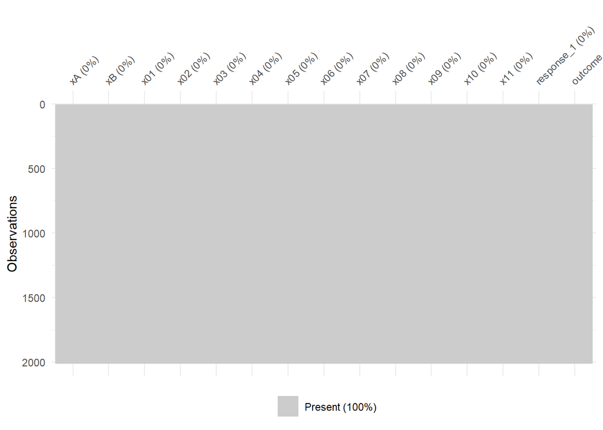

```r
visdat::vis_miss(df)
```

There are no missing values in the data-set

Visualizing the type of data in the data-set

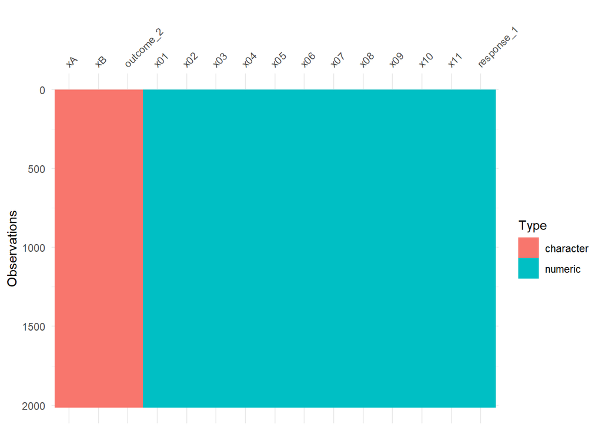

```r
visdat::vis_dat(df)
```

xA, xB and outcome_2 are character type data. While all the other fields are numeric.

No. of unique values in the variables in the data

```r
df %>% purrr::map_dbl(~length(unique(.)))
```

```
##         xA         xB        x01        x02        x03        x04        x05
##          4          2       2013       2013       2013       2013       2013
##        x06        x07        x08        x09        x10        x11 response_1
##       2013       2013       2013       2013       2013       2013       2013
##  outcome_2
##          2
```

Looking at the first few values of the data-set

```r
head(df)
```

```
## # A tibble: 6 x 15
##   xA    xB      x01   x02   x03   x04   x05   x06   x07   x08   x09   x10   x11
##   <chr> <chr> <dbl> <dbl> <dbl> <dbl> <dbl> <dbl> <dbl> <dbl> <dbl> <dbl> <dbl>
## 1 A1    B1     83.5  288.  120.  383.  338.  345.  360.  327.  108.  356.  59.8
## 2 A1    B1     83.5  291.  130.  338.  330.  308.  383.  304.  117.  356.  58.1
## 3 A1    B1     86.3  350.  116.  357.  354.  334.  387.  330.  139.  370.  62.0
## 4 A1    B1     84.9  300.  144.  387.  297.  354.  384.  345.  139.  284.  62.0
## 5 A1    B1     82.5  329.  124.  348.  380.  330.  351.  279.  148.  365.  60.9
## 6 A1    B1     81.0  270.  120.  270.  243.  308.  361.  415.  138.  385.  57.6
## # ... with 2 more variables: response_1 <dbl>, outcome_2 <chr>
```

Separating variables associated with Option A classification formulation.

```r
df_A <- df %>% select(xA, xB, x01:x11, outcome_2) %>%
  mutate(outcome_2 = factor(outcome_2, levels = c("Fail", "Pass")))

df_A %>% glimpse()
```

```
## Rows: 2,013
## Columns: 14
## $ xA        <chr> "A1", "A1", "A1", "A1", "A1", "A1", "A1", "A1", "A1", "A1", ~
## $ xB        <chr> "B1", "B1", "B1", "B1", "B1", "B1", "B1", "B1", "B1", "B1", ~
## $ x01       <dbl> 83.54072, 83.54778, 86.32736, 84.86205, 82.46256, 80.99029, ~
## $ x02       <dbl> 287.7955, 290.8875, 349.7162, 299.6924, 329.2035, 269.7590, ~
## $ x03       <dbl> 119.8126, 130.1864, 115.5560, 143.8517, 123.6961, 119.8614, ~
## $ x04       <dbl> 383.3652, 337.7157, 357.4333, 387.0575, 347.6050, 270.1010, ~
## $ x05       <dbl> 338.3202, 330.4228, 354.0787, 297.0156, 379.7120, 243.2995, ~
## $ x06       <dbl> 344.8461, 307.6132, 333.8511, 353.8841, 330.2676, 308.4986, ~
## $ x07       <dbl> 359.6313, 382.9059, 386.8669, 384.2229, 351.4782, 360.5119, ~
## $ x08       <dbl> 327.1143, 303.9343, 330.2342, 345.0382, 279.2042, 415.4756, ~
## $ x09       <dbl> 108.2988, 117.3816, 138.7686, 139.0503, 147.9659, 137.9829, ~
## $ x10       <dbl> 356.0947, 356.0769, 369.9678, 284.0267, 365.2057, 384.8564, ~
## $ x11       <dbl> 59.78659, 58.14254, 61.95862, 62.03022, 60.93901, 57.64180, ~
## $ outcome_2 <fct> Pass, Fail, Pass, Pass, Fail, Fail, Pass, Pass, Fail, Pass, ~
```

Count of different values under xA:

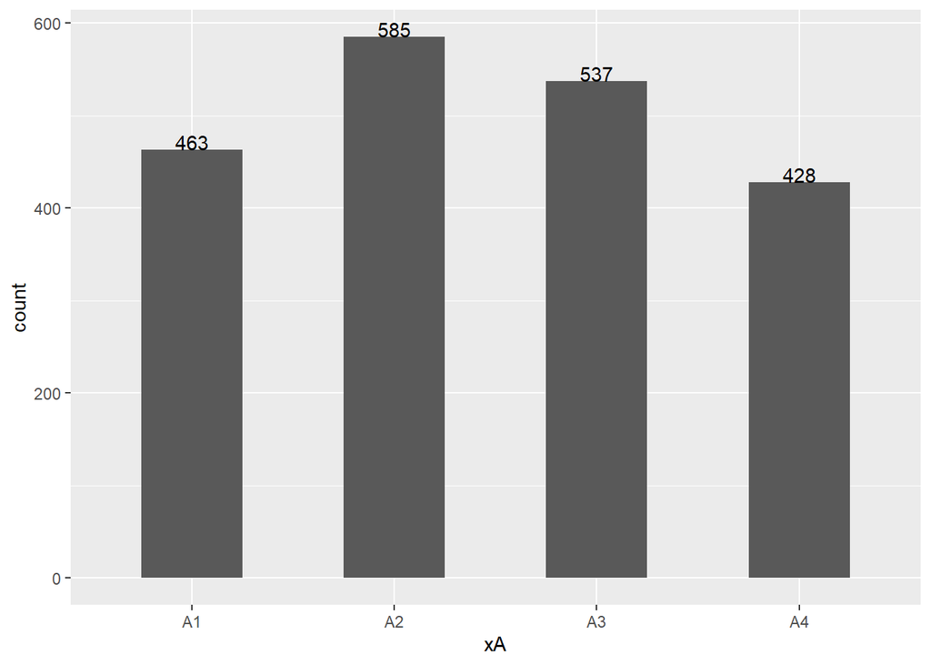

```r
#Bar plots for xA
df %>% ggplot(mapping = aes(x = xA))+
  geom_bar(width = 0.5)+
  geom_text(stat = 'count', aes(label = ..count..), vjust = 0)
```

Count of different values under xB:

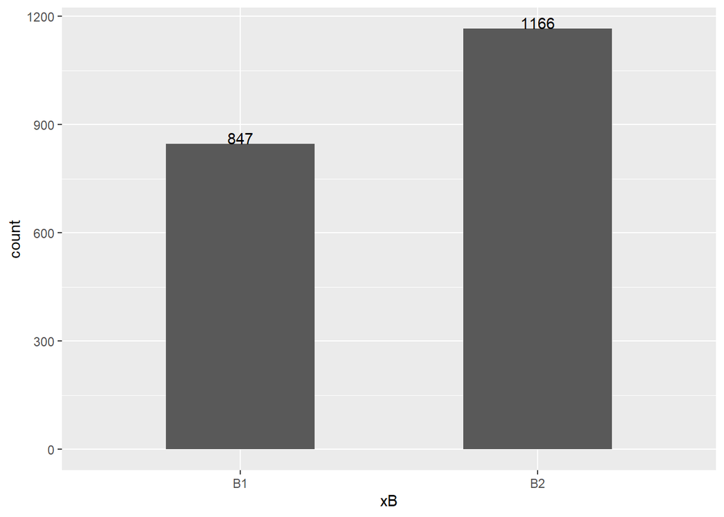

```r
#Bar plots for xA
df %>% ggplot(mapping = aes(x = xB))+
  geom_bar(width = 0.5)+
  geom_text(stat = 'count', aes(label = ..count..), vjust = 0)
```

```r
summary(df)
```

```
##       xA                 xB                 x01             x02
##  Length:2013        Length:2013        Min.   :77.12   Min.   :223.6
##  Class :character   Class :character   1st Qu.:81.37   1st Qu.:295.8
##  Mode  :character   Mode  :character   Median :82.49   Median :313.3
##                                        Mean   :82.53   Mean   :313.2
##                                        3rd Qu.:83.73   3rd Qu.:330.8
##                                        Max.   :87.96   Max.   :392.5
##       x03             x04             x05             x06
##  Min.   :111.3   Min.   :214.7   Min.   :218.9   Min.   :285.7
##  1st Qu.:124.3   1st Qu.:350.6   1st Qu.:335.0   1st Qu.:330.5
##  Median :127.9   Median :376.8   Median :357.8   Median :340.7
##  Mean   :127.9   Mean   :377.0   Mean   :357.3   Mean   :340.9
##  3rd Qu.:131.8   3rd Qu.:405.6   3rd Qu.:379.9   3rd Qu.:351.5
##  Max.   :146.8   Max.   :500.0   Max.   :469.6   Max.   :392.9
##       x07             x08             x09              x10
##  Min.   :274.2   Min.   :217.7   Min.   : 89.92   Min.   :259.4
##  1st Qu.:361.1   1st Qu.:300.2   1st Qu.:122.44   1st Qu.:328.3
##  Median :378.3   Median :321.1   Median :131.06   Median :343.0
##  Mean   :378.6   Mean   :320.6   Mean   :130.99   Mean   :343.0
##  3rd Qu.:395.5   3rd Qu.:342.3   3rd Qu.:139.36   3rd Qu.:358.1
##  Max.   :468.1   Max.   :416.6   Max.   :178.89   Max.   :425.6
##       x11          response_1        outcome_2
##  Min.   :51.34   Min.   :-30.5376   Length:2013
##  1st Qu.:61.12   1st Qu.: -1.9160   Class :character
##  Median :63.43   Median :  0.4441   Mode  :character
##  Mean   :63.51   Mean   :  0.5003
##  3rd Qu.:65.90   3rd Qu.:  3.2791
##  Max.   :74.71   Max.   : 29.5693
```

```r
#Finding the range for convenience

conti_var <- df %>%   #Data-set with all continuous inputs
  select(x01:x11, response_1)

for (i in 1:ncol(conti_var)){
  print(paste0(colnames(conti_var[i]), " : ", max(conti_var[,i])-min(conti_var[,i]) ))
}
```

```
## [1] "x01 : 10.844959209916"
## [1] "x02 : 168.830978478124"
## [1] "x03 : 35.4946956685525"
## [1] "x04 : 285.278746836021"
## [1] "x05 : 250.626943029358"
## [1] "x06 : 107.231956043599"
## [1] "x07 : 193.944467505975"
## [1] "x08 : 198.926361779866"
## [1] "x09 : 88.971945038181"
## [1] "x10 : 166.21138987391"
## [1] "x11 : 23.3659325875584"
## [1] "response_1 : 60.1069281917606"
```

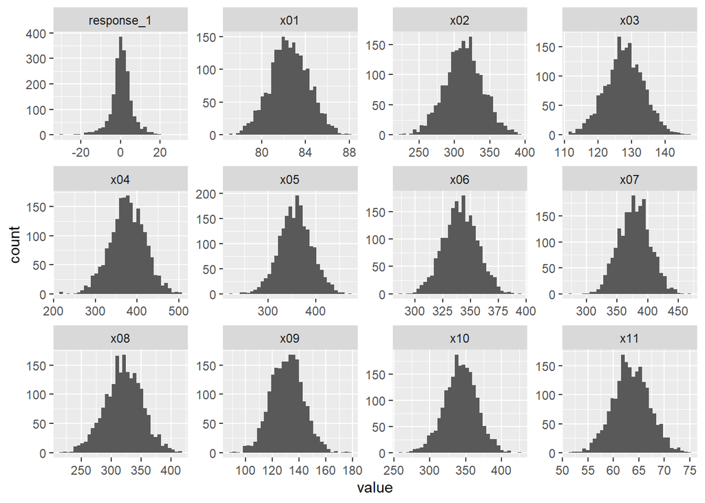

```r
conti_var %>%
  tibble::rowid_to_column() %>%
  pivot_longer(!rowid) %>%
  ggplot(mapping = aes(x = value))+
  geom_histogram(bins = 35)+
  facet_wrap(~name, scales = "free")
```

The continuous variables are predominantly Gaussian, hence there is no need to apply transformations.

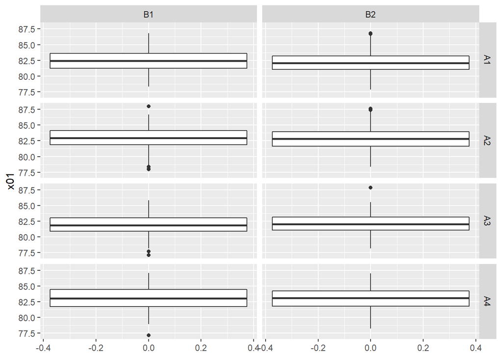

```r
df_A %>%
  ggplot(mapping = aes(y = x01))+
  geom_boxplot()+
  facet_grid(xA~xB)
```

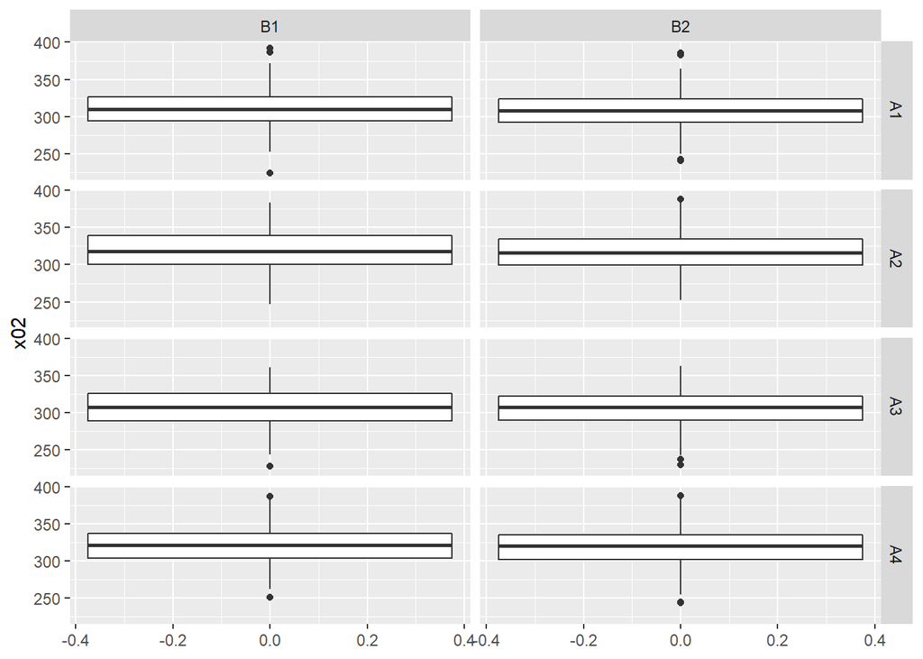

```r
df_A %>%
  ggplot(mapping = aes(y = x02))+
  geom_boxplot()+
  facet_grid(xA~xB)
```

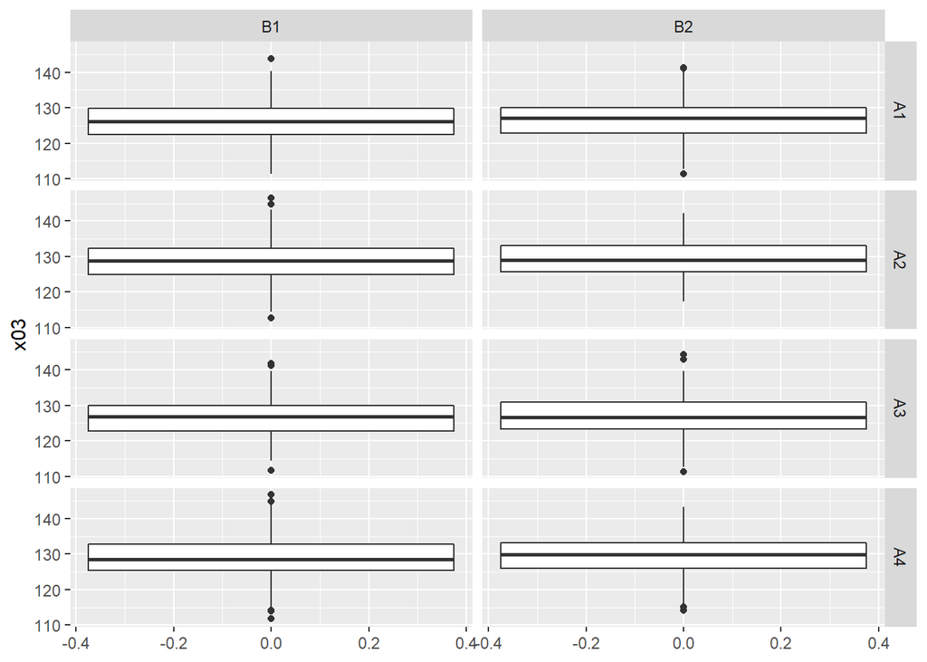

```r
df_A %>%
  ggplot(mapping = aes(y = x03))+
  geom_boxplot()+
  facet_grid(xA~xB)
```

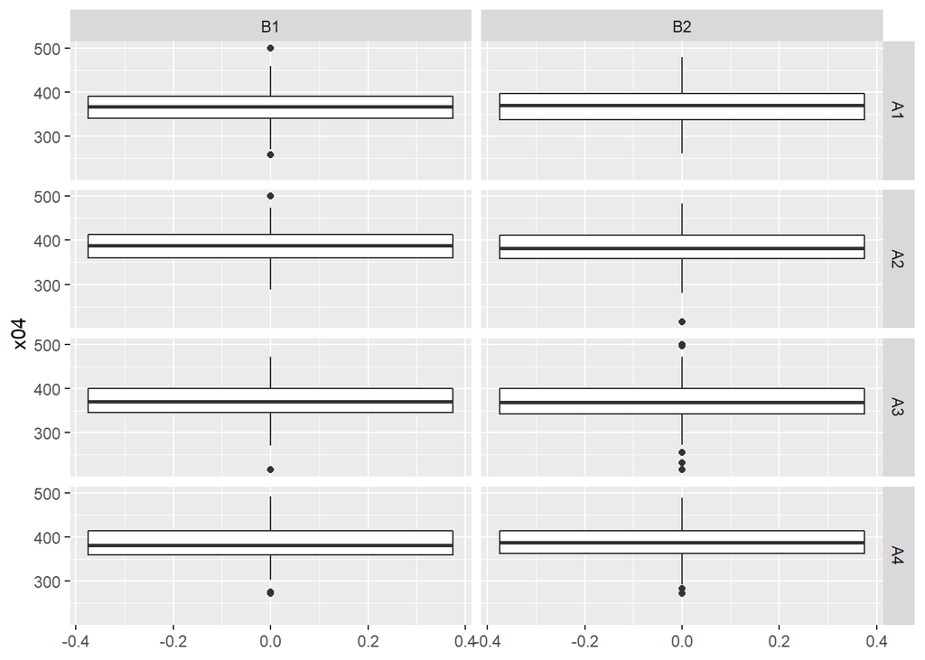

```r
df_A %>%
  ggplot(mapping = aes(y = x04))+
  geom_boxplot()+
  facet_grid(xA~xB)
```

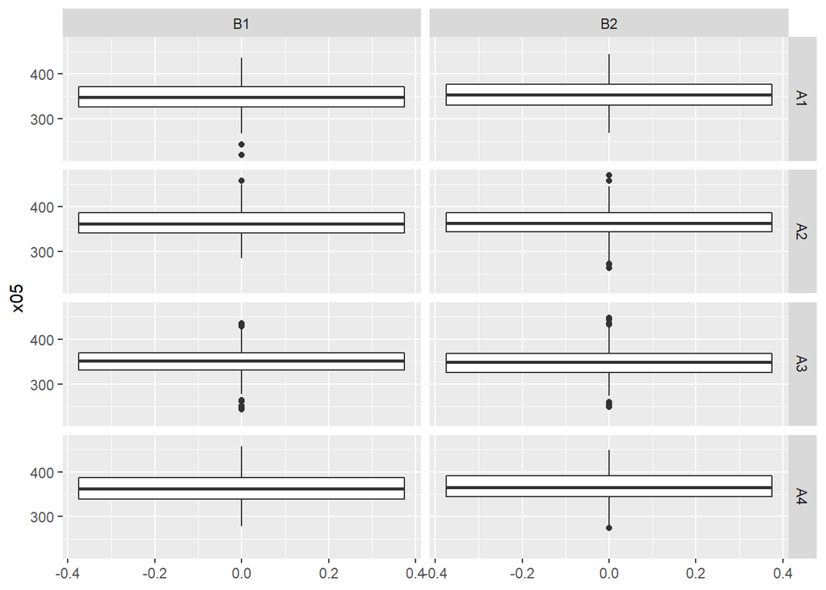

```r
df_A %>%
  ggplot(mapping = aes(y = x05))+
  geom_boxplot()+
  facet_grid(xA~xB)
```

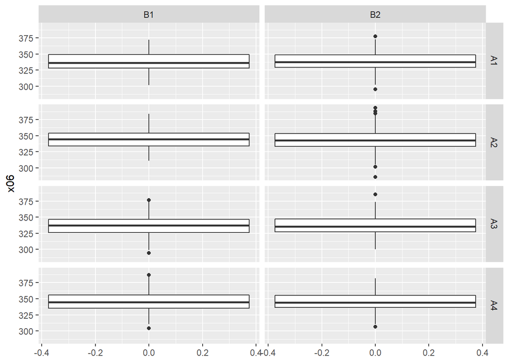

```r
df_A %>%
  ggplot(mapping = aes(y = x06))+
  geom_boxplot()+
  facet_grid(xA~xB)
```

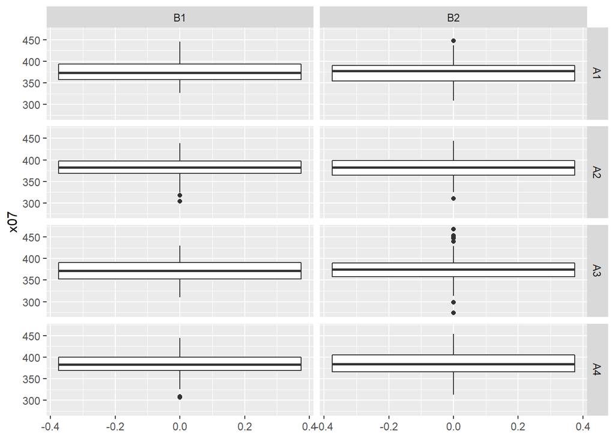

```r
df_A %>%
  ggplot(mapping = aes(y = x07))+
  geom_boxplot()+
  facet_grid(xA~xB)
```

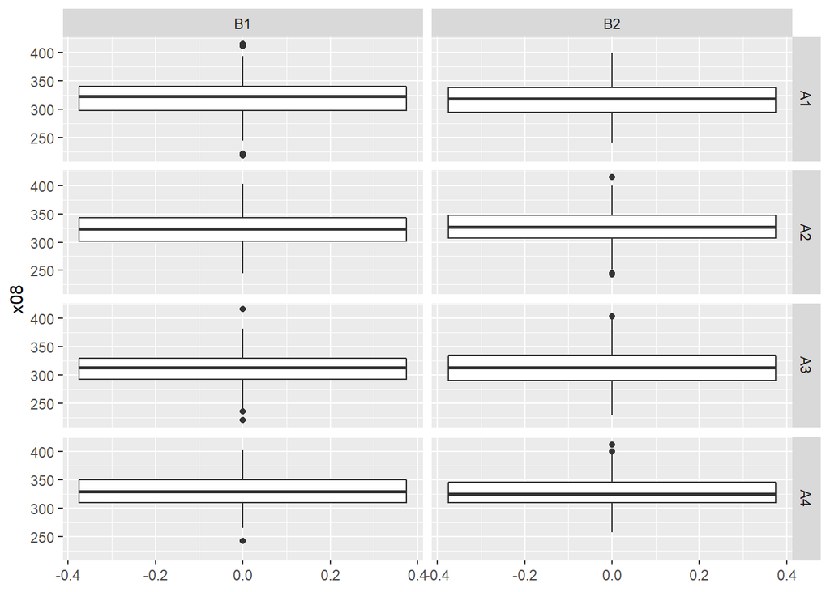

```r
df_A %>%
  ggplot(mapping = aes(y = x08))+
  geom_boxplot()+
  facet_grid(xA~xB)
```

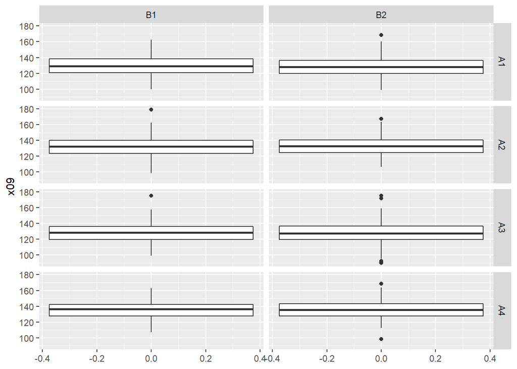

```r
df_A %>%
  ggplot(mapping = aes(y = x09))+
  geom_boxplot()+
  facet_grid(xA~xB)
```

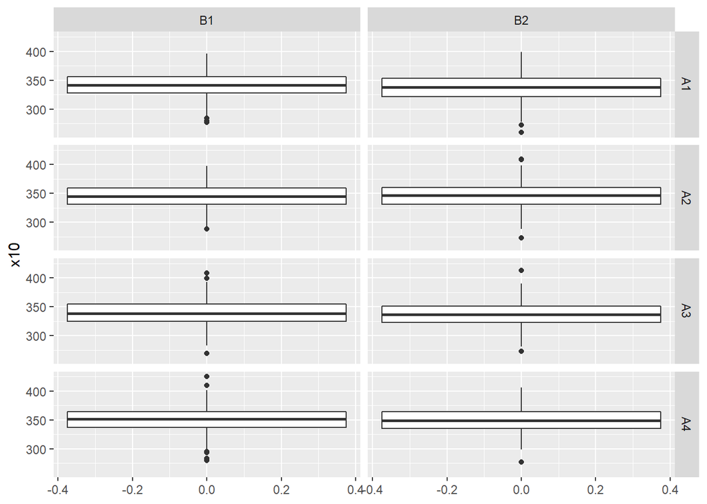

```r
df_A %>%
  ggplot(mapping = aes(y = x10))+
  geom_boxplot()+
  facet_grid(xA~xB)
```

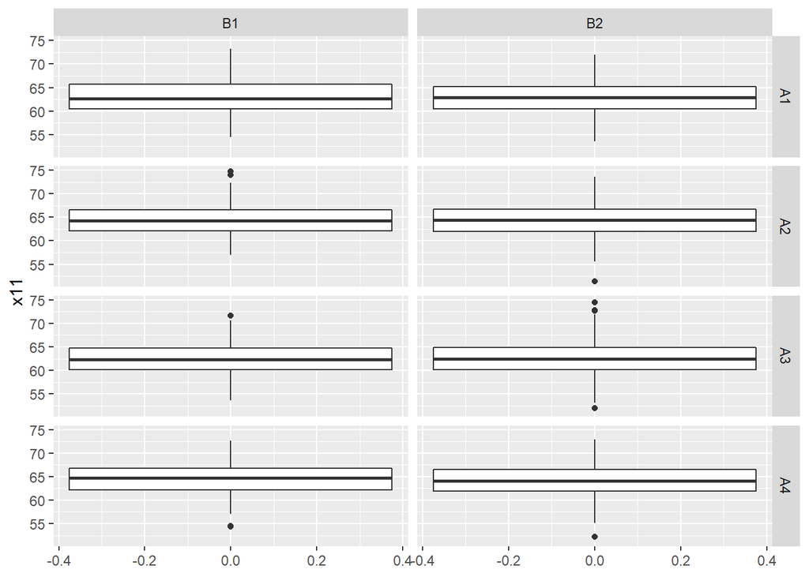

```r
df_A %>%
  ggplot(mapping = aes(y = x11))+
  geom_boxplot()+
  facet_grid(xA~xB)
```

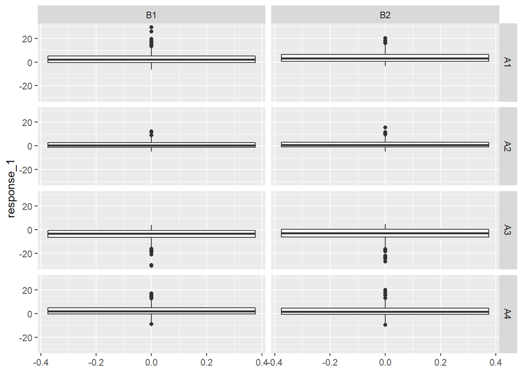

```r
df %>%
  ggplot(mapping = aes(y = response_1))+
  geom_boxplot()+
  facet_grid(xA~xB)
```

Correlation plot for continous inputs

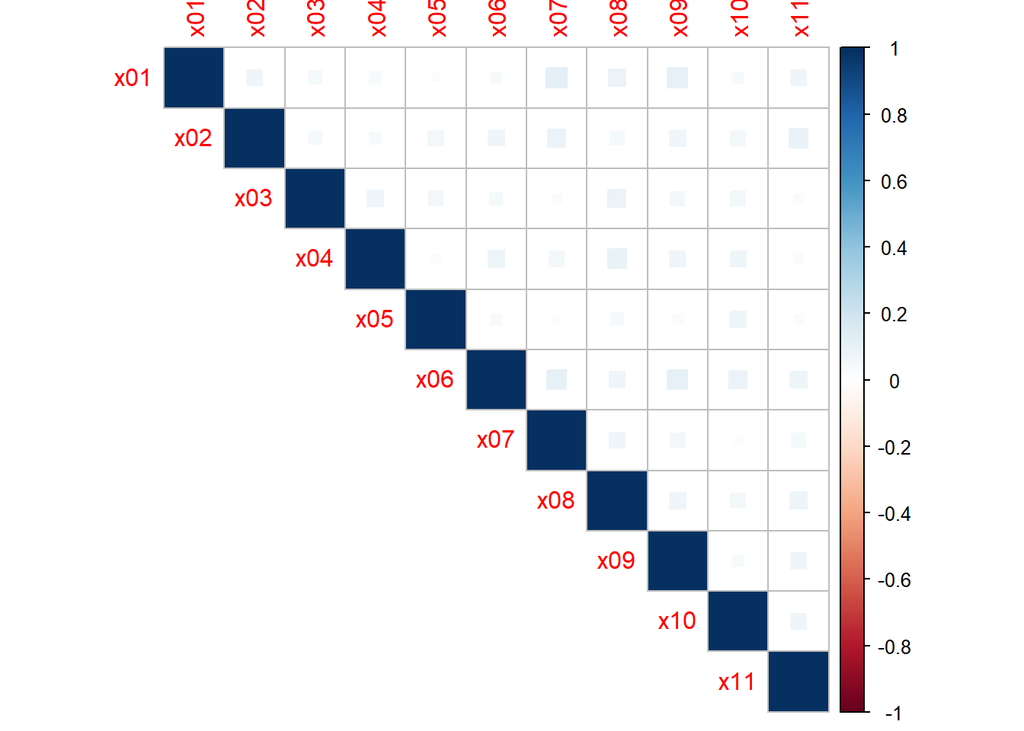

```r
df_A %>%
  purrr::keep(is.numeric) %>%
  cor() %>%
  corrplot::corrplot(type = 'upper', method = 'square')
```

It can be seen that the continuous inputs are not correlated.

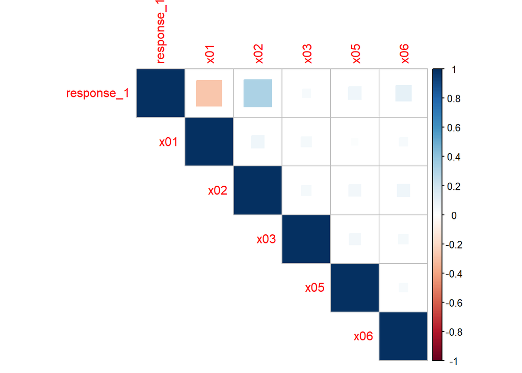

```r
df %>% select (response_1, x01,x02,x03,04,x05,x06) %>%
  cor() %>%
  corrplot::corrplot(type = 'upper', method = 'square')
```

```r
df2 <- df %>%
  mutate(y = ifelse(outcome_2 == 'Fail', 1,0))
```

Shown below is the visualization of outcome_2 wrt response_1

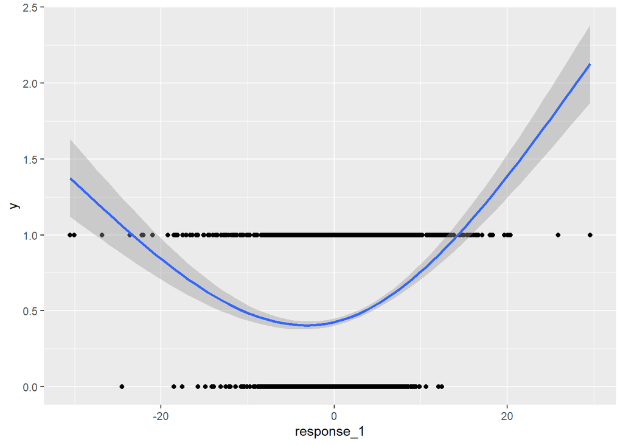

```r
df2 %>%
  ggplot(mapping = aes(x = response_1, y = y))+
  geom_point()+
  geom_smooth(method = "glm", family = 'binomial', formula = y ~ splines::ns(x,2))
```

Now visualizing the behavior between Step 2 inputs and outcome_2

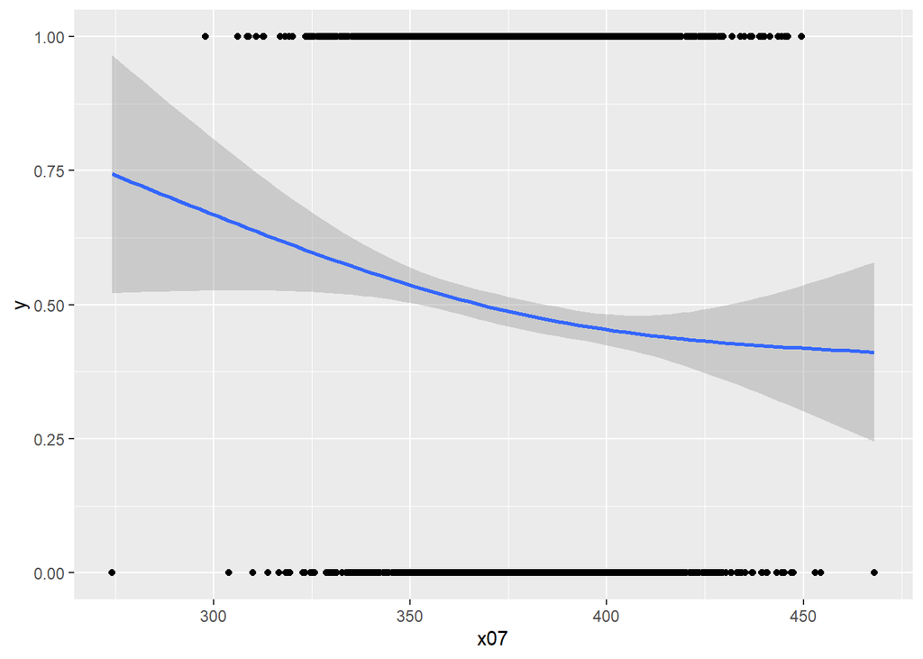

```r
df2 %>%
  ggplot(mapping = aes(x = x07, y = y))+
  geom_point()+
  geom_smooth(method = "glm", family = 'binomial', formula = y ~ splines::ns(x,2))
```

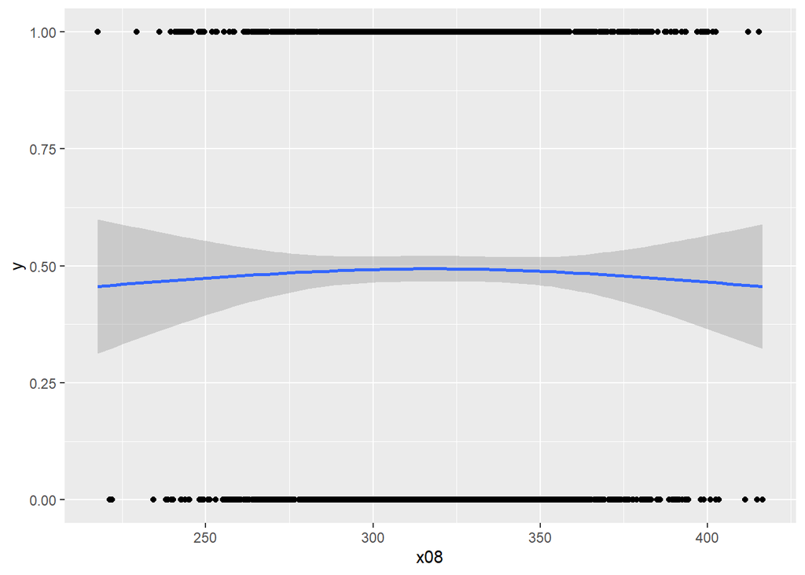

```r
df2 %>%
  ggplot(mapping = aes(x = x08, y = y))+
  geom_point()+
  geom_smooth(method = "glm", family = 'binomial', formula = y ~ splines::ns(x,2))
```

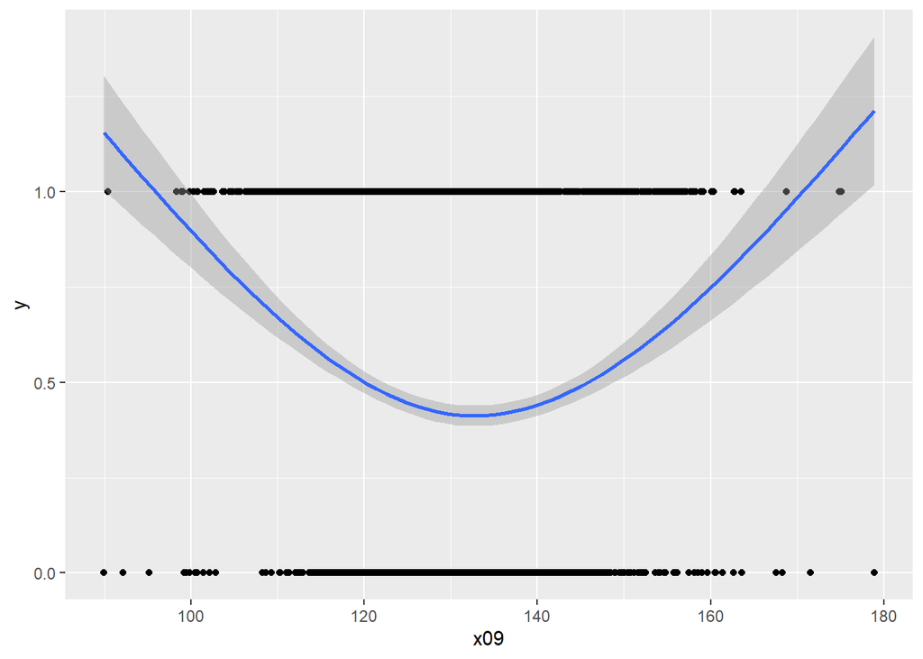

```r
df2 %>%
  ggplot(mapping = aes(x = x09, y = y))+
  geom_point()+
  geom_smooth(method = "glm", family = 'binomial', formula = y ~ splines::ns(x,2))
```

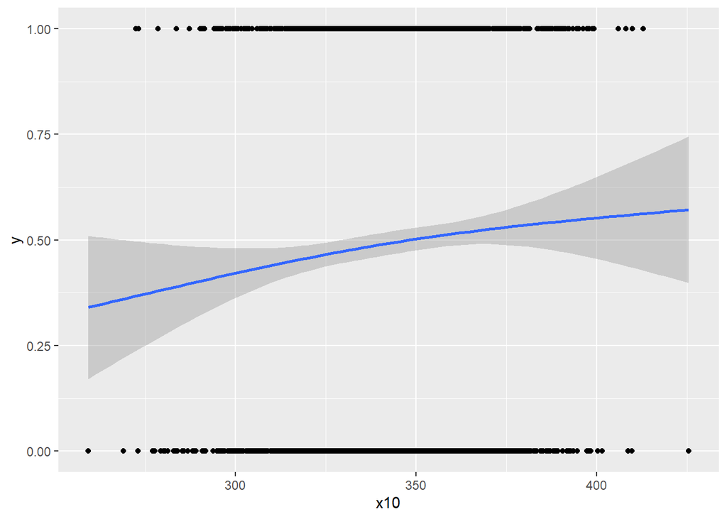

```r
df2 %>%
  ggplot(mapping = aes(x = x10, y = y))+
  geom_point()+
  geom_smooth(method = "glm", family = 'binomial', formula = y ~ splines::ns(x,2))
```

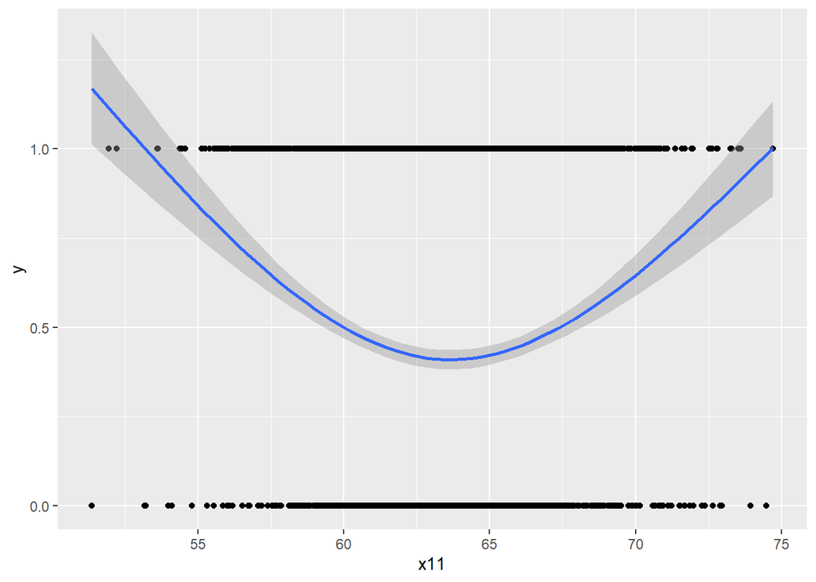

```r
df2 %>%
  ggplot(mapping = aes(x = x11, y = y))+
  geom_point()+
  geom_smooth(method = "glm", family = 'binomial', formula = y ~ splines::ns(x,2))
```